# Cod-Flounder empirical data

1/11/2024

## Loading data

```r
# Stomach data
stom_data <- read_csv("../data/stom_data_light.csv") %>%
  mutate(predator_length_class = ifelse(predator_name == "cod",
                                  paste0("cod_", cut(predator_length_cm, c(-Inf, 20,30,40,50,Inf))),
                                  paste0("flounder_", cut(predator_length_cm, c(-Inf, 20,30,Inf)))))

# Adding taxonomic groups as well as a fish/invertebrate prey type.
    species_groups <-
      read_csv("../data/taxa_groups.csv")

    stom_data <- stom_data %>%
      left_join(species_groups, by = c("prey_latin_name" = "taxa")) %>%
      mutate(prey_type = case_when(species_group == "Clupeidae" ~ "Fish",
                               species_group == "Gobiidae" ~ "Fish",
                               species_group == "Gadiformes" ~ "Fish",
                               species_group == "Other fish" ~ "Fish",
                               TRUE ~ "Invertebrate"))

# Biomass index
cod_fle_index <- read_csv("../data/cod_fle_index.csv")

# Catch density per length cod and flounder (superfluous data removed)
#read_csv("../data/catch_by_length.csv") %>%
#select(density, year, quarter, haul_id, sub_div, length_cm, species) %>%
#filter(sub_div %in% c(25,28) & density > 0 & species %in% c("cod", "flounder")) %>%
#write_csv("cod_fle_size_light.csv")
cod_fle_size <- read_csv("../data/cod_fle_size_light.csv")
```

# Cod-Flounder diet distance

Based on number of prey species found in the stomach content, the diet of different size classes of cod and flounder are compared. The bigger the distance (red), the more different the diet. Can be altered to instead count species group items for an aggregated diet comparison.

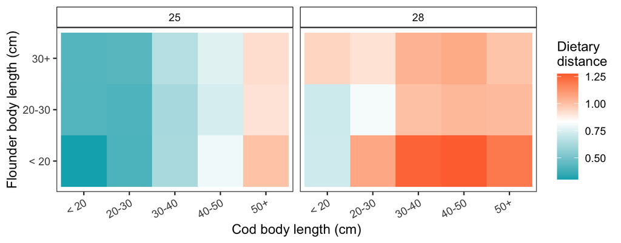

```r
subdiv_dist_all <- function(df){
  subdiv_list <- c(25,28)

  merge_dist <- tibble()

    for(i in subdiv_list){
    prey_df <- df %>%
      filter(!is.na(predator_length_cm) &
               cruise %in% c("BITS", "BITS-1", "BITS-2")) %>% # Standardized fishing methods)
      mutate(predator_length_class = as.factor(predator_length_class)) %>%
      filter(subdiv == i) %>%
      group_by(predator_length_class) %>%
      count(prey_latin_name, .drop = FALSE) %>%
      ungroup() %>% #alt: "prey" / "species_group"
      pivot_wider(names_from = prey_latin_name,
                  values_from = n,
                  values_fill = 0)

      pvpdf <- data.frame(prey_df[,-1])
      rownames(pvpdf) <- pull(prey_df[,1])

      pvpdist <- get_dist(pvpdf, method = "spearman") #Spearman distance less dependent on normal distribution

      pvpdist <- pvpdist %>%
        as.matrix() %>%
        .[6:8,1:5] %>%
        as_tibble(rownames = "flounder") %>%
        pivot_longer(names_to = "cod", cols = 2:6) %>%
        mutate(subdiv = as.character(i), year = "all")

      merge_dist <- bind_rows(merge_dist, pvpdist)
    }
  return(merge_dist)
}

gg_dist <- subdiv_dist_all(stom_data) %>%
  mutate(flounder = case_when(
    flounder == "flounder_(-Inf,20]" ~ "< 20",
    flounder == "flounder_(20,30]" ~ "20-30",
    flounder == "flounder_(30, Inf]" ~ "30+")) %>%
mutate(cod = case_when(
    cod == "cod_(-Inf,20]" ~ "< 20",
    cod == "cod_(20,30]" ~ "20-30",
    cod == "cod_(30,40]" ~ "30-40",
    cod == "cod_(40,50]" ~ "40-50",
    cod == "cod_(50, Inf]" ~ "50+")) %>%
  ggplot() +
  aes(x = cod, y = flounder, fill = value) +
  geom_tile() +
  scale_fill_gradient2(midpoint = (0.35+1.32)/2,
                       low = "#00AFBB", mid = "white", high = "#FC4E07") +
  facet_grid(.~subdiv, scales = "free") +
  theme(axis.text.x = element_text(angle = 30, hjust = 1, vjust = 1)) +
  labs(fill = "Dietary\ndistance",
       x = "Cod body length (cm)", y = "Flounder body length (cm)")
gg_dist
```

# Cod and flounder biomass

From a biomass perspective, cod is predominant over flounder in subdivision 25, whereas the opposite relationship is true in subdivision 28. This can be considered aligned with the pattern in diet overlap, where in subdivision 25, cod diet is more similar to flounder diet.

Note that biomass estimates here are actually the relative abundances instead of absolutes.

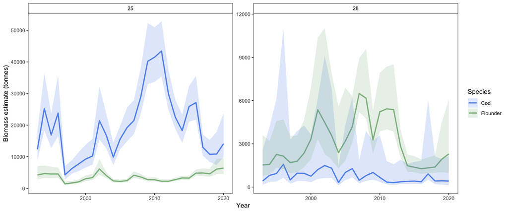

```r
gg_biomass <- cod_fle_index %>%
  dplyr::filter(sub_div %in% c(25,28)) %>%
  dplyr::select(-1) %>%
  mutate(species = case_when(species == "cod" ~ "Cod",
                             species == "fle" ~ "Flounder")) %>%
    ggplot() +
  aes(x = year, y = est_t, ymax = upr_t, ymin = lwr_t,
      color = species, fill = species) +
  geom_line(linewidth = 1) +
  geom_ribbon(alpha = 0.2, color = NA) +
  geom_blank(aes(x = year, y = 11500)) +
  scale_colour_manual(values = c("cornflowerblue", "darkseagreen")) +
  scale_fill_manual(values = c("cornflowerblue", "darkseagreen")) +
  facet_wrap(.~sub_div, scales = "free") +
  labs(x = "Year", y = "Biomass estimate (tonnes)", color = "Species", fill = "Species")
gg_biomass
```

### Fig. 3 Biomass and dietary distance

```r
gg_bio_diet <- plot_grid(gg_biomass, gg_dist, ncol = 1, labels = c("A", "B"))
ggsave(plot = gg_bio_diet, filename = "../fig/fig3.pdf", width = 6.6, height = 5)
```

## Body size distribution

Data is available as density per length class for each haul. In this temporary repository, data for the length classes is limited to 15-75 cm.

First, a look at number of hauls for the respective sub divisions.

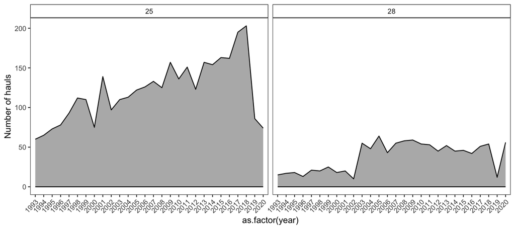

```r
cod_fle_size %>%
  filter(species %in% c("cod", "flounder")) %>%
  filter(sub_div %in% c(25, 28) & quarter %in% c(1,4)) %>%
  group_by(year, sub_div) %>%
  distinct(haul_id) %>%
  ungroup(sub_div) %>%
  count(sub_div) %>%
  ungroup() %>%
  ggplot() +
    aes(x = as.factor(year), y = n, ymax = n, ymin = 0, group = sub_div) +
    geom_ribbon(alpha = 0.4, color = "black") +
    facet_wrap(.~sub_div) +
    labs(y = "Number of hauls", color = "subdiv", fill = "subdiv") +
    theme(axis.text.x = element_text(angle=45, hjust = 1))
```

Due to the somewhat limited data, years are aggregated as the brackets below. Also, due to the difference in sampling frequency, we calculate the proportional biomass per length class instead of the actual density. Rolling averages for the length classes is also used to smooth the low sampling in the earlier year brackets.

```r
# First, aggregating
year_brackets <- c(1992, 2000, 2010, 2020)

d2 <- cod_fle_size %>%
  filter(species %in% c("cod", "flounder")) %>%
  filter(sub_div %in% c(25, 28)) %>%
mutate(length_cm = round(length_cm, digits = 0)) %>%
  mutate(year_cat = cut(year, year_brackets, dig.lab = 10)) %>%
  group_by(year_cat, sub_div, species, length_cm, quarter) %>% #year_cat
  summarise(density = sum(density)) %>%
  ungroup()

# Total density of hauls, used to calculate proportional density
dsum <- cod_fle_size %>%
  filter(species %in% c("cod", "flounder")) %>%
  filter(sub_div %in% c(25, 28)) %>%
  mutate(length_cm = round(length_cm, digits = 0)) %>%
  mutate(year_cat = cut(year, year_brackets, dig.lab = 10)) %>%
  group_by(year_cat, sub_div, species, quarter) %>% #year_cat
  summarise(tot_density = sum(density)) %>%
  ungroup()

# Proportional density
d3 <- d2 %>%
  left_join(dsum, by = c("year_cat", "sub_div", "species", "quarter")) %>%
  mutate(prop = density / tot_density)
  # group_by(year_cat, species, sub_div) %>%
  # summarise(prop_tot = sum(prop)) %>%
  # ungroup()

# Q4 Mean length based on density of length classes
  dmean_q4 <- d3 %>%
  filter(length_cm > 0 & quarter %in% c(4)) %>%
  mutate(year_cat = case_when(
    year_cat == "(1992,2000]" ~ "1993-2000",
    year_cat == "(2000,2010]" ~ "2001-2010",
    year_cat == "(2010,2020]" ~ "2011-2020")) %>%
  mutate(n = ceiling(density)) %>%
  group_by(species, year_cat, sub_div, quarter) %>%
  summarise(meanlength = sum(length_cm * n) / sum(n)) %>%
  ungroup()

  # Q1 Mean length based on density of length classes
  dmean_q1 <- d3 %>%
  filter(length_cm > 0 & quarter %in% c(1)) %>%
  mutate(year_cat = case_when(
    year_cat == "(1992,2000]" ~ "1993-2000",
    year_cat == "(2000,2010]" ~ "2001-2010",
    year_cat == "(2010,2020]" ~ "2011-2020")) %>%
  mutate(n = ceiling(density)) %>%
  group_by(species, year_cat, sub_div, quarter) %>%
  summarise(meanlength = sum(length_cm * n) / sum(n)) %>%
  ungroup()
```

# Fig. 4 Plotting length distributions

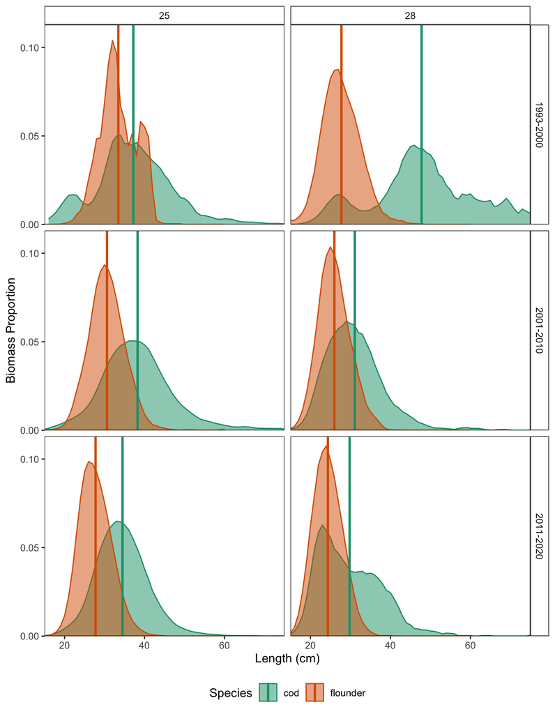

```r
pally <- "Dark2"
gg_length_dist <- d3 %>%
  filter(length_cm > 0 & quarter %in% c(4)) %>%
  # rollprop = Moving 3 year average
  mutate(rollprop = stats::filter(prop, filter = rep(1/3, 3), sides = 2)) %>%
  mutate(year_cat = case_when(
    year_cat == "(1992,2000]" ~ "1993-2000",
    year_cat == "(2000,2010]" ~ "2001-2010",
    year_cat == "(2010,2020]" ~ "2011-2020")) %>%
  ggplot() +
  aes((length_cm), ymin = 0, ymax = rollprop,
      fill = as.factor(species), color = as.factor(species)) +
  geom_ribbon(alpha = 0.5) +
 geom_vline(data = dmean_q4,
aes(xintercept = meanlength,
    color = fct_relevel(species, c("flounder", "cod"))), linewidth = 1) +
  facet_grid(year_cat ~ sub_div) +
  scale_color_brewer(palette = pally) +
  scale_fill_brewer(palette = pally) +
  scale_y_continuous(breaks = c(0,0.05,0.1), expand = expansion(mult = c(0,0.05))) +
  scale_x_continuous(expand = expansion(mult = c(0,00))) +
  coord_cartesian(xlim = c(15,75)) +
  labs(#subtitle = "Lines indicate mean and 95% quantiles (dashed)",
       x = "Length (cm)", y = "Biomass Proportion", color = "Species", fill = "Species") +
  theme(legend.position = "bottom") +
  NULL
gg_length_dist
```

```r
ggsave(filename = "../fig/fig4.pdf", plot = gg_length_dist, width = 5, height = 4)
```

# Fig. S2 Plotting length distributions

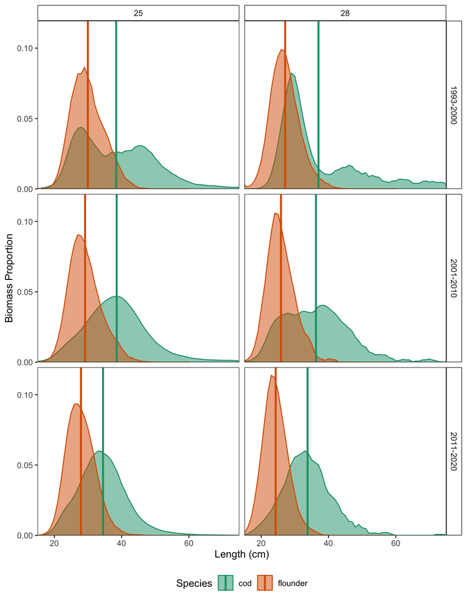

```r
pally <- "Dark2"
gg_length_dist_q1 <- d3 %>%
  filter(length_cm > 0 & quarter %in% c(1)) %>%
  # rollprop = Moving 3 year average
  mutate(rollprop = stats::filter(prop, filter = rep(1/3, 3), sides = 2)) %>%
  mutate(year_cat = case_when(
    year_cat == "(1992,2000]" ~ "1993-2000",
    year_cat == "(2000,2010]" ~ "2001-2010",
    year_cat == "(2010,2020]" ~ "2011-2020")) %>%
  ggplot() +
  aes((length_cm), ymin = 0, ymax = rollprop,
      fill = as.factor(species), color = as.factor(species)) +
  geom_ribbon(alpha = 0.5) +
 geom_vline(data = dmean_q1,
aes(xintercept = meanlength,
    color = fct_relevel(species, c("flounder", "cod"))), linewidth = 1) +
  facet_grid(year_cat ~ sub_div) +
  scale_color_brewer(palette = pally) +
  scale_fill_brewer(palette = pally) +
  scale_y_continuous(breaks = c(0,0.05,0.1), expand = expansion(mult = c(0,0.05))) +
  scale_x_continuous(expand = expansion(mult = c(0,00))) +
  coord_cartesian(xlim = c(15,75)) +
  labs(#subtitle = "Lines indicate mean and 95% quantiles (dashed)",
       x = "Length (cm)", y = "Biomass Proportion", color = "Species", fill = "Species") +
  theme(legend.position = "bottom") +
  NULL
gg_length_dist_q1
```

```r
ggsave(filename = "../fig/figs2.pdf", plot = gg_length_dist, width = 5, height = 4)
```

## Fig. S3 Dietary proportions

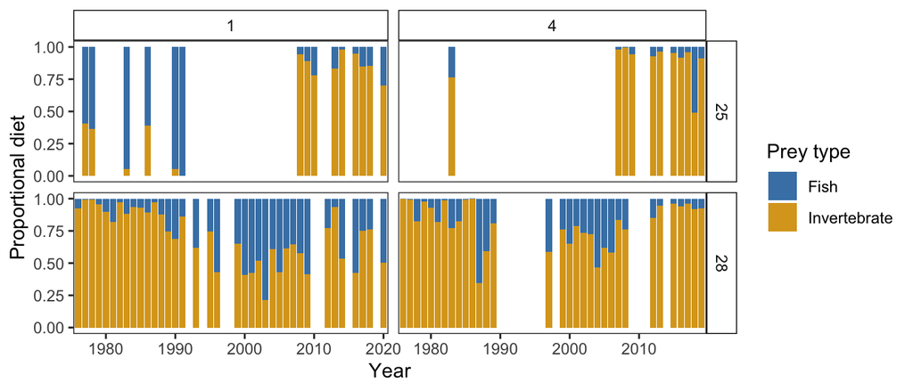

```r
gg_cod_proportional_fish <- stom_data %>%
  filter(quarter %in% c(1,4) &
           !is.na(species_group) &
           year >= 1976 &
           predator_length_cm %in% 15:40 &
           subdiv %in% c(25,28)
         ) %>%
  group_by(predator_name, subdiv, year, quarter) %>%
  count(prey_type) %>%
  ungroup() %>%
  mutate(pred_div = paste0(predator_name, "_", subdiv)) %>%
  mutate(pred_div  = factor(pred_div)) %>%
  filter(predator_name == "cod") %>%
  ggplot() +
    aes(x = year, y = n, fill = prey_type) +
    geom_bar(stat = "identity", position = "fill") + #
    scale_fill_manual(values = c("steelblue", "goldenrod"))  +
    scale_x_continuous(expand = expansion(add = c(0.25,0.25))) +
    facet_grid(subdiv~quarter, scales = "free_x", space = "free_x") +
    labs(y = "Proportional diet", x = "Year", fill = "Prey type")
gg_cod_proportional_fish
```

```r
ggsave(filename = "../fig/figs3.pdf", plot = gg_cod_proportional_fish, width = 8, height = 3)
```